# My Report-Assignment 4

Laila Gmerek

2023-08-03

# Introduction and Summary Statistics

In the United States, the issue of incarceration presents a complex and pressing challenge. With America having the highest number of people incarcerated in the world, this phenomenon disproportionately affects people of color, especially Black individuals, due to historical and present-day racism. The consequences of these disparities are far-reaching, necessitating a deeper analysis of the trends and factors contributing to the unequal distribution of incarceration rates.

This assignment focuses on using data analysis and visualization to uncover patterns of inequality within the prison and jail populations. The data is sourced from the Vera Institute, a reputable organization collecting information on incarceration trends. The datasets under consideration provide insights into prison population per county/state, jail population per county/state, and the rate of incarceration per 100,000 people.

The aim of this analysis is twofold: first, to understand the trajectory of prison and jail populations over time; second, to examine how race and gender intertwine with these trends. By conducting this investigation, we hope to identify potential solutions and shed light on areas that require greater attention from the public and policymakers.

As the sole researcher on this project, I have carefully chosen specific variables to analyze, considering their relevance in illuminating the complex dynamics of incarceration in America. Through this exploration, I seek to contribute to a broader understanding of the challenges faced by impacted communities and advocate for social justice and equity.

## Variables for Analysis

For this analysis, I have chosen the following key variables:

```
## [1] 84300.51
```

- **Median Total Population:** The median population represents the middle value of the prison population per county/state when arranged in ascending order. By utilizing the median, we can better assess the central tendency and identify areas where the distribution of incarcerated individuals might be skewed.

```
## [1] 22970
```

- **Standard Deviation Population:** The standard deviation measures the extent to which prison population data varies from the mean. A higher standard deviation suggests more significant variability in incarceration rates across different regions, indicating potential disparities or areas of concern.

```
## [1] 303312.1
```

```
## [1] 10120540
```

- **Minimum Population:** The minimum population gives the lowest value of the prison population per county/state. By examining the minimum, we can identify regions with relatively lower incarceration rates, potentially indicating areas where reform efforts or successful interventions have been implemented.

```
## [1] 0
```

The min of the total population is 0

# Data

### Data Collection

The data for this assignment was collected by the Vera Institute of Justice. They have compiled county- and jurisdiction-level jail data from 1970 to 2018 and prison data from 1983 to 2016. Additionally, state-level prison data for the years 2019 to 2021 is also included in the dataset.

### Data Collection Method

The data was collected through various sources and data collections, including the Census of Jails (COJ) and the Annual Survey of Jails (ASJ), conducted by the Bureau of Justice Statistics (BJS). The COJ covers all jails and is conducted every five to eight years since 1970, while the ASJ covers about one-third of jails, including most of the largest jails, and is conducted in non-census years since 1982. The National Corrections Reporting Program (NCRP) data collection is also used for county-level data.

### Purpose of Data Collection

The data was collected to provide a comprehensive understanding of incarceration trends in the United States. By examining jail and prison incarceration data at the county and jurisdiction levels, the Vera Institute seeks to analyze the causes and consequences of high incarceration rates. The ultimate goal is to inform the public dialogue, advance research, and guide changes to justice policy and practice, particularly concerning mass incarceration and its impact on communities.

### Columns

There are 36 columns in the data set

### Rows

There are 153,811 rows

### Ethical Considersations

When working with incarceration data, ethical considerations related to privacy and consent are important. The data likely contains sensitive information about individuals who have been incarcerated. Therefore, researchers must ensure that the data is appropriately anonymized and aggregated to protect the identities of those individuals. Additionally, any analysis that involves demographic characteristics, such as race and gender, should be approached with sensitivity and an understanding of the potential implications of the findings.

### Limitations and Problems

One possible limitation of the data is that it may not cover more recent years for some variables, as the latest state-level prison data is available up to the year 2021. Researchers should be mindful of potential data gaps and consider how they might impact the analysis.

Another limitation may be the potential underrepresentation of smaller jails or jurisdictions, as the data relies on the Annual Survey of Jails, which covers about one-third of jails. This could introduce sampling biases that need to be taken into account during analysis.

Furthermore, while the dataset provides valuable insights into incarceration trends, it may not capture all factors influencing incarceration rates comprehensively. Additional contextual factors, such as socioeconomic status, drug policies, and other systemic issues, could play a role in the observed trends and would require careful consideration in the analysis.

Researchers should also be aware of any potential biases in the data collection process, such as reporting discrepancies or changes in data collection methodologies over time, which could impact the accuracy and reliability of the findings.

In summary, while the dataset provided by the Vera Institute offers valuable information on incarceration trends, researchers must approach its analysis with awareness of its limitations and potential ethical implications.

# Trends Over Time Chart

## Prison Population of the Top Two States in the US from 1970-2020

[figure not shown]

# Variable Comparison Chart

## White Prison Population vs. Black Prison Population

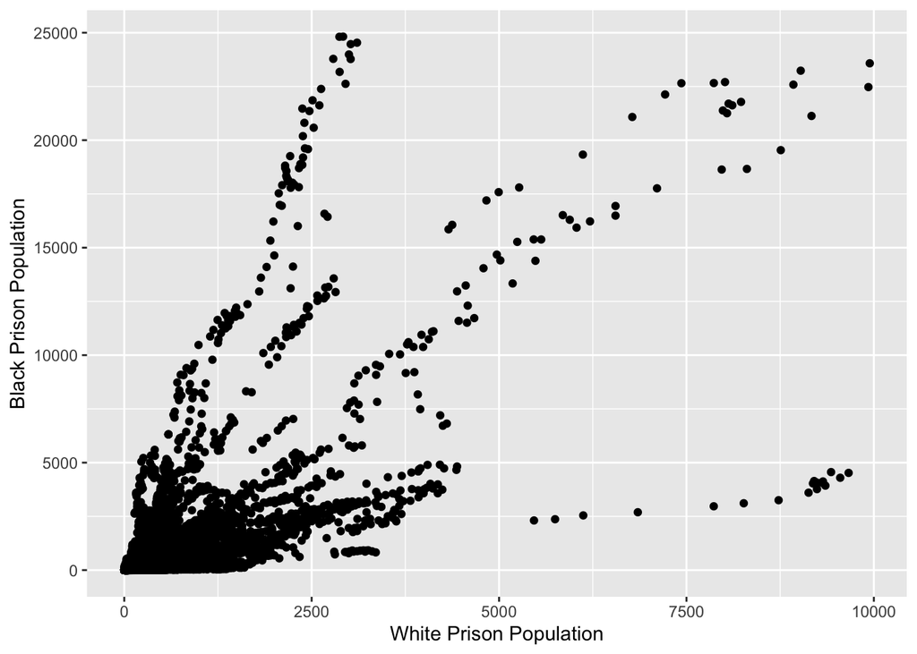

The Variable Comparison Chart illustrates the relationship between the white and black prison populations over time. The chart showcases a scatter plot with each point representing the corresponding data point in the dataset. The x-axis represents the ‘White Prison Population,’ and the y-axis represents the ‘Black Prison Population.’ As we observe the chart, we can discern patterns and trends that indicate how the two variables are related to each other. This comparison aims to shed light on any disparities or potential correlations in the prison populations between white and black individuals. As one can see the Black Prison Population extents into the 20,000s, while the White Prison Population does not exceed 10,000.

# Map

## Prison Population Map

[figure not shown]